# *Welcome to Nyquist's Final Project: Telling Stories for INFO 1201*

### Research Query

In the FiveThirtyEight online journal, Walt Hickey's article "Comic Books Are Still Made By Men, For Men And About Men" spoke about how despite the possible fanbase, Marvel and DC comics focus on their heterosexual male viewers more than anyone else. Through his collection of data, data which I use here for my questions, he was able to create graphs and charts to analyze the information about these characters in new contexts. Information about the sex and sexuality, alignment, release date and appearances, living status, and colors of each character were able to be recorded. Although there was a heavy focus on the lack of representation gender-wise, I wanted to expand upon his conclusions by both examining the gender gaps a bit further, while also examining another source of information: eye color.  
Although Walt's data is expansive, it doesn't contain any information about ethnicity or race, a factor that Walt's also assumed would be biased towards the mostly white male fanbase the comics were catering to. Whether this information was recorded in the Wikia databases he retrieved other data from or not, I believe this information can still be to some degree viewed through the colors that the characters are given, especially through eye color. The vast majority of people have black or brown eyes, with blue or green eyes found mostly in white people. Seeing how the eye colors are represented in these comics, as well as taking a closer look at gender distributions in certain contexts, is the focus of this data analysis.

### Computational Thinking Approach

To begin the analysis, I first had to work with others to both obtain the data and figure out what to do with it. The data, consisting of 23,420 characters total, was collected through Walt Hickey from databases made by other people. In class, Shiva taught us the basics of the code, how it worked, and even provided a skeleton that we could remix and work from to create graphs that answered our own questions. People in class were able to showcase any workarounds they found, either through Shiva's permission or through showcases, as this project was cumulative.  
Moving this project along required generating questions that could be answered with the data. After creating questions, I experimented with how to use the data, iterating on previous code to develop more concise and/or more broadened information. Code skeletons were added to, subtracted from, and customized to work with the data in my specific contexts. Any errors led to more questions, whether they were in how to make the code work or to find an alternate solution.  
At the end of the project, I had to envision how I wanted the overall project to look. Though the code was more modularized and separated in the beginning (for learning and understanding), the final involved deleting any code that no longer served the main theme or abstract of my project. In the end, through generating questions and creating my own visuals, the project's final touches involved coding the data to best express the answers of my questions. Color, images, and hierarchy became important to make the research legible and easily understood. The finished presentation, neatly organizing the data into distinct questions and context, was created through these computational practices and principles.

# *Part 1: Gender Distributions*

[figure not shown]

#### Question 1: How does the distribution of secret identities differ between bad characters of different genders?

There is certainly a bias towards gender and the alignment of an individual. In Walt's analysis, his "Good Girls Gone Meh" chart showed how the percentage of males put in the bad alignment differed from women, who more often had a neutral or good role. These differences led to my question of how secret identities would be distributed per gender of bad characters. Would males be the least likely to have secret identities, and conversely, would women be the most likely?  
A bar plot is used so that the percentages of secret identities from each gender of bad characters can be better compared, while also disregarding the number of characters of each gender. A crosstab between sex, alignment, and identity was created, calculating the percentage/decimal of each to use for the bar chart. To only use confirmed data in my analysis, I dropped any values with no data, which has decreased the number of characters in the analysis by some extent.

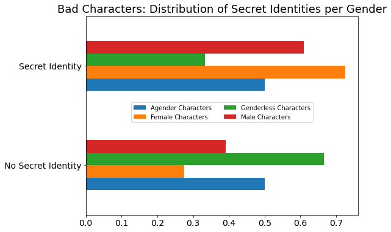

```python
# I imported pandas and numpy, two libraries used in python that have functions to simplify data analysis
import pandas as pd
import numpy as np
#import the libraries
import matplotlib.pyplot as plt

#this will display graphs in line
%matplotlib inline
#specifying how large to show the figures
plt.rcParams["figure.figsize"]=(8,6)

#----------------------------------------------------------------------------------------------------------------------

# The variable superheroes means that python will use a pandas function to read the excel data sheet, organizing by the numbers in FIRST_YEAR column
superheroes = pd.read_csv("superheroTSdata.csv", parse_dates = ["FIRST_YEAR"])



#i should drop any characters that are not bad or secret
secretA = superheroes.drop(superheroes[superheroes.SEX == "ND"].index)
secretB = secretA.drop(secretA[secretA.ID == "ND"].index)

secretbad = pd.crosstab(index = secretB["ID"] == ("Secret Identity"), columns = [secretB["ALIGN"] == ("Bad Characters"), secretB["SEX"]], normalize='columns')
#print(secretbad)
#print(secretbad[True])
savehere = secretbad[True]
#normalize = index/columns (https://pbpython.com/pandas-crosstab.html) or .apply(lambda r: r/r.sum())

#sometimes, crosstabs work just like dataframes, so the language can be used from there (since the .replace didn't work)
identity = savehere.rename(index={True: 'Secret Identity',False: 'No Secret Identity' })

# https://stackoverflow.com/questions/14281871/given-a-pandas-series-that-represents-frequencies-of-a-value-how-can-i-turn-tho
#counts = secretK['SEX'].value_counts(normalize = True)

identity.plot(kind = "barh", fontsize = 14)
plt.legend(loc="lower center", bbox_to_anchor=(0.5, .45), ncol=2)
plt.ylabel("")
#plt.y_labels = ["secret", "not secret"]
plt.title("Bad Characters: Distribution of Secret Identities per Gender", fontsize = 18)
plt.show()
```

##### Findings and Limitations

This graph examines the distribution of bad characters' secret identities per gender. There are differing results from this bar chart. The percentage of bad agender characters that have secret identites is equivalent to those without one. Bad genderless characters have the least percentage of secret identities compared to other genders. There is a greater percentage of bad male characters that have a secret identity than bad male characters with other indentities. However, out of all of them, bad female characters have the most percentage of characters with secret identities than without.  
Unfortunately, there were many characters that had no data related to these keys and so were removed from the plot. Their lack of data is moreso from data collection rather than an actual lack of said traits for these missing characters, so there is some information missing. Additionally, this bar plot does not show the distribution of all identites in bad characters.

#### Question 2: How do the percentages of each gender differ between nonheterosexual characters?

Although the amount of characters that are heterosexual is extensively greater than those that are not heterosexual, further questions could be asked about representation within nonheterosexual characters. Nodding to previous inquiries about gender distribution, I wanted to look at the distribution of gender in nonheterosexual characters.  
I decided to use a pie chart to compare these two keys. Pie charts work best when only two (or less) categories are being examined, instead of multiple. I dropped any heterosexual characters from the data. I was able to avoid dropping any characters for no data because, surprisingly, no nonheterosexual characters had a lack of data in these categories.

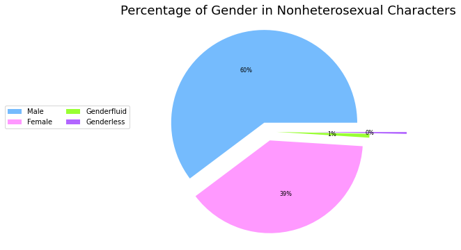

```python
homosexualGG = superheroes.drop(superheroes[superheroes.SEXUALITY == "Heterosexual Characters"].index)
counts = homosexualGG["SEX"].value_counts()
#print(counts)

homotc = ["xkcd:sky blue", "#ff99ff", "#99ff33", "#b266ff"]

counts.plot(kind = "pie", colors = homotc, explode=(.1, .1, .1, .5), labels=['','','',''], autopct = "%1.0f%%", fontsize = 8)
plt.title("Percentage of Gender in Nonheterosexual Characters", fontsize = 18)
#zains example = plt.pie(whatYourePlotting, labels=yourLabels, explode=(0.1, 2, 1), autopct='%1.0f%%')

#make plot have even axes so the pie chart is perfectly circular
plt.axis ("equal")

plt.legend(["Male", "Female", "Genderfluid", "Genderless"], loc="lower right", bbox_to_anchor=(.001, .5), ncol=2)

#get rid of y and x axis label SEX - this wasn't working on my end
plt.axes().set_ylabel('')
plt.axes().set_xlabel('')

plt.show()
```

##### Findings and Limitations

In looking at the distribution of gender in nonheterosexual characters, once can see that the majority of nonheterosexual characters are male, taking up almost two thirds of the pie chart. Female characters are second in number, taking up more than a third of the pie chart. There are barely any genderfluid and genderless characters shown in the pie chart, with genderless characters being shown at almost zero percent.  
Because there were no characters with no data, there is nothing missing from this data set. However, since the comic franchises are attempting to be more inclusive and representational due to their change in focus of their fanbase, any new characters with these traits are missing from the data. The dataset ends at 2014, which leaves seven years of new characters not listed and analyzed.

# *Part 2: Eye Color Distributions*

[figure not shown]

#### Question 3: How does the distribution of eye color differ between the alignment of characters?

From the data that Walt's collected, he inquired about how race and ethnicity is represented in Marvel and DC comics, since their perceived fanbase was white males for much of their existence. Although he collected no data investigating this specifically, eye color can be used as a basis for examining race-related questions, since white populations tend to have blue or green eyes compared to other skin tones. I decided to investigate the distribution of eye color between aligned characters because I wanted to see if there were any biases with eye color specifically.  
Pie charts were used to examine how eye color distributions varied per alignment. Because of the amount of categories being viewed, three pie charts were created so that the percentages between the three could be compared easily. Each eye color is visually represented through color in the pie chart, allowing better legibility. Several types of values were dropped, such as those with no data, those with incorrect data (hair information rather than eye), and those describing eye type or multitude. Additionally, certain eye colors were grouped together, such as those distinguished by "eyeballs" and "eyes," and similar eye colors such as violet and purple or silver and gray. Characters with eyes that changed through time were grouped with an eye color that matched their current eye color. All of these edits have changed the distributions of the data, but these edits were meant to be more for clarity and were done in the attempt to be as unbiased as possible.

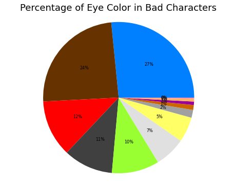

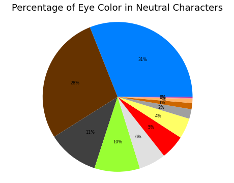

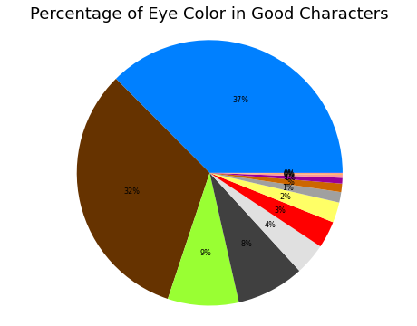

```python
dropND = superheroes.drop(superheroes[superheroes.EYES == "ND"].index)
dropOne = dropND.drop(dropND[dropND.EYES == "One Eye"].index)
dropNo = dropOne.drop(dropOne[dropOne.EYES == "No Eyes"].index)
dropMulti = dropNo.drop(dropNo[dropNo.EYES == "Multiple Eyes"].index)
dropHair = dropMulti.drop(dropMulti[dropMulti.EYES == "Auburn Hair"].index)
dropComp = dropHair.drop(dropHair[dropHair.EYES == "Compound Eyes"].index)
dropPhoto = dropComp.drop(dropComp[dropComp.EYES == "Photocellular Eyes"].index)
tdropVar = dropPhoto.drop(dropPhoto[dropPhoto.EYES == "Variable Eyes"].index)

tcombineeyes = tdropVar
tcombineeyes = tcombineeyes.replace("Brown Eyes formerly Amber formerly Green", "Brown Eyes")
tcombineeyes = tcombineeyes.replace("Brown Eyes formerly Blue Eyes", "Brown Eyes")
tcombineeyes = tcombineeyes.replace("Blue Eyes formerly Green", "Blue Eyes")
tcombineeyes = tcombineeyes.replace("Red Eyes formerly Blue Eyes", "Red Eyes")
tcombineeyes = tcombineeyes.replace("Yellow Eyeballs", "Yellow Eyes")
tcombineeyes = tcombineeyes.replace("Black Eyeballs", "Black Eyes")
tcombineeyes = tcombineeyes.replace("Amber Eyes", "Yellow Eyes")
tcombineeyes = tcombineeyes.replace("Gold Eyes", "Yellow Eyes")
tcombineeyes = tcombineeyes.replace("Hazel Eyes; White Eyes", "Hazel Eyes")
tcombineeyes = tcombineeyes.replace("Silver Eyes", "Grey Eyes")
tcombineeyes = tcombineeyes.replace("Violet Eyes", "Purple Eyes")

#----------------------------------------------------------------------------------------------------------------------

feye_colors = ["#0080ff", "#663300", "#ff0000", "#404040", "#99ff33", "#e0e0e0", "#ffff66", "#a0a0a0", "#cc6600", "#990099", "#ffb266", "#ff9999", "#ff00ff"]


eyegood = tcombineeyes.drop(tcombineeyes[tcombineeyes.ALIGN == "Good Characters"].index)
eyeneutral = eyegood.drop(eyegood[eyegood.ALIGN == "Neutral Characters"].index)
eyeND = eyeneutral.drop(eyeneutral[eyeneutral.ALIGN == "ND"].index)
eyeref = eyeND.drop(eyeND[eyeND.ALIGN == "Reformed Criminals"].index)
eyeNDt = eyeref.drop(eyeref[eyeref.EYES == "ND"].index)
counts = eyeNDt["EYES"].value_counts()
#print(counts)

plt.figure(0)
counts.plot(kind = "pie", labels=None, colors = feye_colors, autopct = "%1.0f%%", fontsize = 8)
plt.title("Percentage of Eye Color in Bad Characters", fontsize = 18)

#make plot have even axes so the pie chart is perfectly circular
plt.axis ("equal")

#get rid of y and x axis label SEX - this wasn't working on my end
plt.axes().set_ylabel('')
plt.axes().set_xlabel('')

#----------------------------------------------------------------------------------------------------------------------

teye_colors = ["#0080ff", "#663300", "#404040", "#99ff33", "#e0e0e0", "#ff0000", "#ffff66", "#a0a0a0", "#cc6600", "#ffb266", "#ff9999", "#990099"]

teyegood = tcombineeyes.drop(tcombineeyes[tcombineeyes.ALIGN == "Good Characters"].index)
teyebad = teyegood.drop(teyegood[teyegood.ALIGN == "Bad Characters"].index)
teyeND = teyebad.drop(teyebad[teyebad.ALIGN == "ND"].index)
teyeref = teyeND.drop(teyeND[teyeND.ALIGN == "Reformed Criminals"].index)
teyeNDt = teyeref.drop(teyeref[teyeref.EYES == "ND"].index)
countfs = teyeNDt["EYES"].value_counts()
#print(countfs)

plt.figure(1)
countfs.plot(kind = "pie", labels=None, colors = teye_colors, autopct = "%1.0f%%", fontsize = 8)
plt.title("Percentage of Eye Color in Neutral Characters", fontsize = 18)


#make plot have even axes so the pie chart is perfectly circular
plt.axis ("equal")

#get rid of y and x axis label SEX - this wasn't working on my end
plt.axes().set_ylabel('')
plt.axes().set_xlabel('')

#----------------------------------------------------------------------------------------------------------------------

geye_colors = ["#0080ff", "#663300", "#99ff33", "#404040", "#e0e0e0", "#ff0000", "#ffff66", "#a0a0a0", "#cc6600", "#990099", "#ff9999", "#ffb266", "#ff00ff"]

feyebad = tcombineeyes.drop(tcombineeyes[tcombineeyes.ALIGN == "Bad Characters"].index)
feyeneutral = feyebad.drop(feyebad[feyebad.ALIGN == "Neutral Characters"].index)
feyeND = feyeneutral.drop(feyeneutral[feyeneutral.ALIGN == "ND"].index)
feyeref = feyeND.drop(feyeND[feyeND.ALIGN == "Reformed Criminals"].index)
feyeNDt = feyeref.drop(feyeref[feyeref.EYES == "ND"].index)
countsg = feyeNDt["EYES"].value_counts()
#print(countsg)

plt.figure(2)
countsg.plot(kind = "pie", labels=None, colors = geye_colors, autopct = "%1.0f%%", fontsize = 8)
plt.title("Percentage of Eye Color in Good Characters", fontsize = 18)

#make plot have even axes so the pie chart is perfectly circular
plt.axis ("equal")

#get rid of y and x axis label SEX - this wasn't working on my end
plt.axes().set_ylabel('')
plt.axes().set_xlabel('')

plt.show()
```

##### Findings and Limitations

The percentage of blue-eyed characters is greatest in good characters, and least in bad characters. This pattern is repeated when looking at brown-eyed characters. Converstely, red-eyed characters have a greater percentage in bad characters, with the least being in good characters. This pattern can be observed at a much lower scale with black, white, green, and yellow eye colors, though their differences may not be statistically significant. In each alignment, blue eyes are the most common eye color, despite this not being the case realistically. Around forty percent of the eye colors are brown or black in each alignment, when once again, realistically, this eye color should be much more prevalent.  
Dropping any character with no data. or characters with no eye color description, reduced the size of the characters being examined. Due to the significantly small size of the reformed criminal alignment, that was also dropped in the comparison, which removed some characters. Although the data is meant to be as unbiased as possible, the grouping of similar eye colors together could have been done through personal opinion, which could change how the distribution is being represented. Additionally, this analysis is based on characters of fantasy and unrealistic abilities most of the time, so eye color can't consistently determine whether characters are being misrepresented compared to a real population. However, the prevalence of certain eye colors brings to question whether the fanbase moreso preferred some colors over others.

#### Question 4: How many characters of each eye color were introduced per year?

Expanding upon the last question, this question is meant to compare the actual numbers of characters with each eye color, rather than the percentages. It's meant to visually represent how many characters with each eye color is added per year, and allows observation to whether these eye color trends have been changing as Marvel's and DC's perception of their fanbases changes. Both universes are beginning to add more diverse characters to foster more inclusivity in their fanbases. Would the eye colors of new characters be a response to that?  
A line graph is used for its indication of time, and shows the number of times a new character (and their eye color) is introduced per year. Characters with no data are once again dropped so that we only investigate confirmed data. A legend is used to distinguish each eye color, with the lines coded to visually represent the color of each. The data was dropped (no data, eye multitude, incorrect information) and combined (similar colors, "eyeballs" vs "eyes," focus on current eye colors rather than former) as it was for the previous question, except reformed criminals are not dropped. The data cuts off at 2014, leaving any characters created after this time unrepresented.

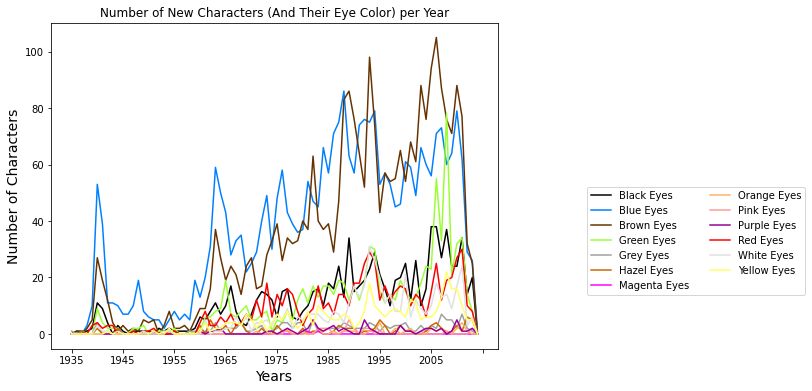

```python
dropND = superheroes.drop(superheroes[superheroes.EYES == "ND"].index)
dropOne = dropND.drop(dropND[dropND.EYES == "One Eye"].index)
dropNo = dropOne.drop(dropOne[dropOne.EYES == "No Eyes"].index)
dropMulti = dropNo.drop(dropNo[dropNo.EYES == "Multiple Eyes"].index)
dropHair = dropMulti.drop(dropMulti[dropMulti.EYES == "Auburn Hair"].index)
dropComp = dropHair.drop(dropHair[dropHair.EYES == "Compound Eyes"].index)
dropPhoto = dropComp.drop(dropComp[dropComp.EYES == "Photocellular Eyes"].index)
dropVar = dropPhoto.drop(dropPhoto[dropPhoto.EYES == "Variable Eyes"].index)
dropNDYR = dropVar.drop(dropVar[dropVar.FIRST_YEAR == "ND"].index)

combineeyes = dropNDYR
combineeyes = combineeyes.replace("Brown Eyes formerly Amber formerly Green", "Brown Eyes")
combineeyes = combineeyes.replace("Brown Eyes formerly Blue Eyes", "Brown Eyes")
combineeyes = combineeyes.replace("Blue Eyes formerly Green", "Blue Eyes")
combineeyes = combineeyes.replace("Red Eyes formerly Blue Eyes", "Red Eyes")
combineeyes = combineeyes.replace("Yellow Eyeballs", "Yellow Eyes")
combineeyes = combineeyes.replace("Black Eyeballs", "Black Eyes")
combineeyes = combineeyes.replace("Amber Eyes", "Yellow Eyes")
combineeyes = combineeyes.replace("Gold Eyes", "Yellow Eyes")
combineeyes = combineeyes.replace("Hazel Eyes; White Eyes", "Hazel Eyes")
combineeyes = combineeyes.replace("Silver Eyes", "Grey Eyes")
combineeyes = combineeyes.replace("Violet Eyes", "Purple Eyes")


eyefirstappearance = pd.crosstab(combineeyes['FIRST_YEAR'], combineeyes['EYES'])

eye_colors = ["#000000", "#0080ff", "#663300", "#99ff33", "#a0a0a0", "#cc6600", "#ff00ff", "#ffb266", "#ff9999", "#990099", "#ff0000", "#e0e0e0", "#ffff66"]

eyefirstappearance.plot(color = eye_colors)
plt.legend(loc="lower right", bbox_to_anchor=(1.7, .15), ncol=2)
plt.title("Number of New Characters (And Their Eye Color) per Year")
plt.xlabel("Years", fontsize = 14)
plt.ylabel("Number of Characters", fontsize = 14)
plt.show()
```

##### Findings and Limitations

In most years, blue-eyed characters are the most added characters per year. An exception seems to be growing, with brown-eyed characters being added more frequently each year since around 1995. Black-eyed charcters are also increasing in additions per year, and combining them with brown-eyed characters may make them have significantly more additions than blue-eyed characters in recent years. Still, the high frequency of new blue-eyed and, recently, green-eyed characters does not reflect the real human population. However, it seems there is some trend for more characters with black or brown eyes, as well as an increase for more "fun," creative but unrealistic eye colors such as yellow or white.  
Once again, certain colors were grouped together based on their perceived similarity, and character data was dropped if it was incorrect or incomplete, which may have skewed results. There is no data from 2014 up, leaving unanswered questions of how the past seven years have changed the frequency of eye color in new characters. The fall at the end of the line graph is incorrect, and is only there because there was only one character addition documented from 2014.

## Acknowledgements

#### Remixes

- Most of the code: Shiva Darian
- Comparing three values in a table: Michael Ghattas
- Code used to explode out pie charts: Zain Elsell
- How to use color in graphs and charts: https://matplotlib.org/stable/tutorials/colors/colors.html
- Legend customization: https://matplotlib.org/stable/api/_as_gen/matplotlib.pyplot.legend.html
- Color hexes: https://www.rapidtables.com/web/color/RGB_Color.html
- Markdown customization: https://github.com/adam-p/markdown-here/wiki/Markdown-Cheatsheet#images

##### Walt Hickey's Article and Analysis: https://fivethirtyeight.com/features/women-in-comic-books/

##### Image sources found in Markdown